# ThrombinCL

# Notes for Analysing Thrombin Generation Curves

A help tab in the app summarises the main features of ThrombinCL version 0.6 and above. More details are presented below.

# Calibrator and Sample data

### Calibrator tab

The app opens with the Calibrator tab and example files of calibrator and sample data are loaded. You can load and examine your own data here. All time course data should be formated as a single column of time in column 1 followed by columns of fluorescence data as a csv file.

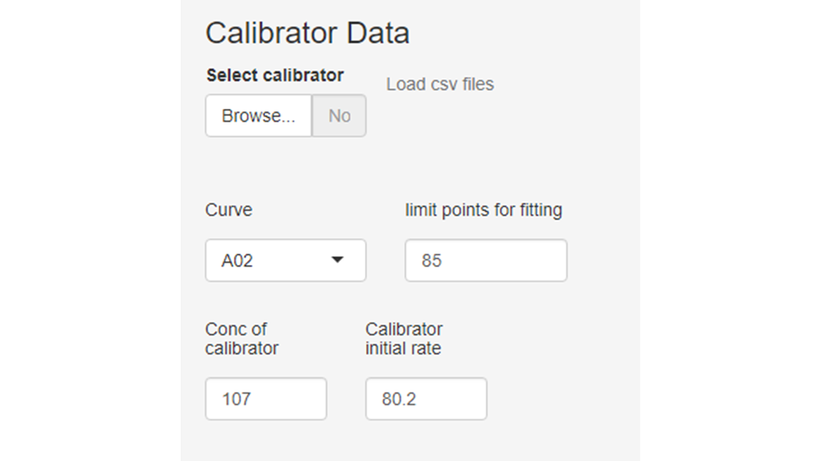

The program fits a curve to your calibrator data (blue lines and symbols) and calculates the initial rate of hydrolysis and initial fluorescence reading, as shown below. The initial rate is extrapolated over the whole time course (red) and a polynomial correction applied to correct for substrate depletion and inner filter effect, to generate the green points. This correction can then be applied similarly to the sample data if desired. It may be necessary to limit the points to be fitted as longer times and high fluorescence degrade the fit.

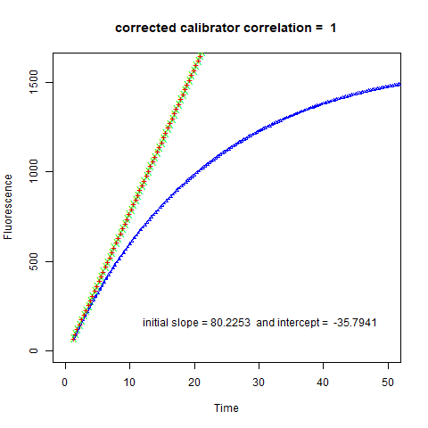

The calculated slope and calibrator concentration used are entered into the appropriate boxes.

Sample fluorescence data are loaded in the same csv format as the calibrator and are shown as plots of fluorescence versus time.

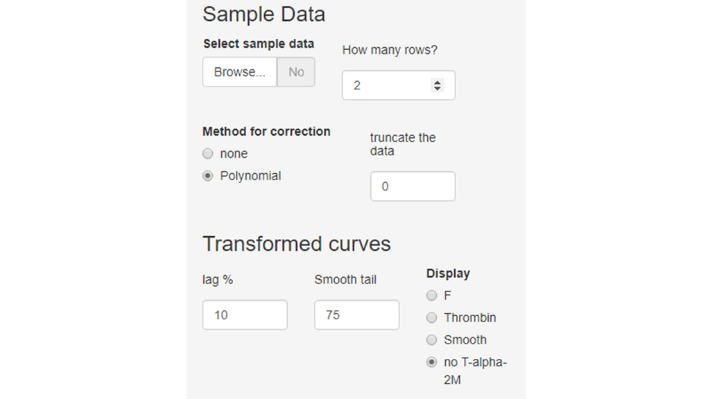

The organisation of the plots can be changed by using the *How many rows* numerical input box. Here the effect of the polynomial correction on the sample data curves can be investigated using the radio buttons. Raw data are shown in blue and corrected curves are red.

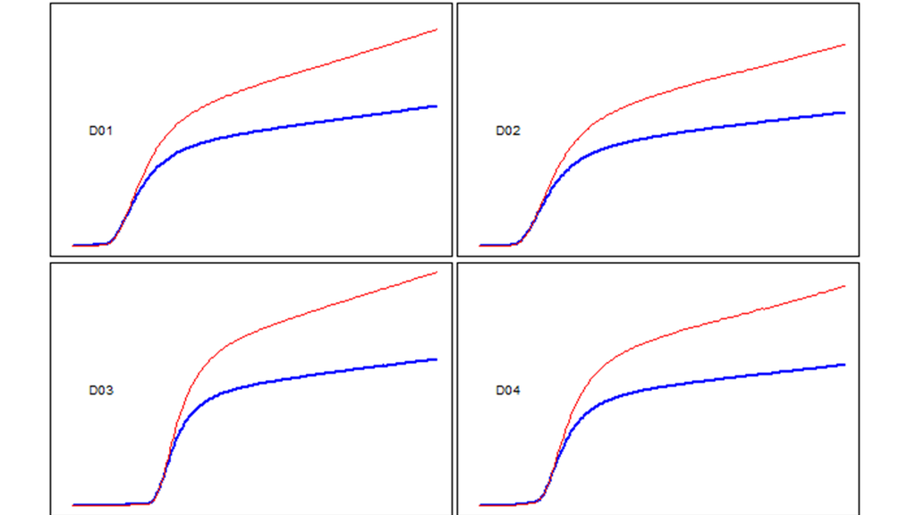

# Data analysis

### Plots

The second tab shows plots after first derivative tranformation in the same arrangement as the the raw fluorescence in the *Calibrator tab*. Other relevant options can be chosen with guidance from these curves. It might be useful to truncate the data by eliminating late points if the traces go on for too long. The initiation point is selected using the *% for initiation* input box and determines where the lag time ends. The default is 10%, which means the lag time is calculated at the point where there is a 10% increase in thrombin concentration. Smoothing the tail sets the number of points from the end of the curves where smoothing will take place and should be adjusted to where the curves have flattened out. The final level calculated is important to generate the response for the thrombin-alpha-2-macroglubulin complex activity. The final set of options on the left hand pane, *Display*, determine what curves will be displayed:

*F* = fluorescence

*Thrombin* = Thrombin concentration calculated from the calibrator concentration and rate entered earlier

*Smooth*= shows the region of curve smoothing

*no T-alpha2M* = subtraction the contribution of the thrombin-alpha-2-macroglubulin complex.

The main pane shows the resulting curves and a parameter can be chosen using the radio buttons which is added to the plots and generates a table of results. The results update as options are updated on the left pane. A dashed green line is retained on all the plots to show the uncorrected thrombin curves. The gold line is the calculated activity of the thrombin-alpha-2-macroglobulin complex.

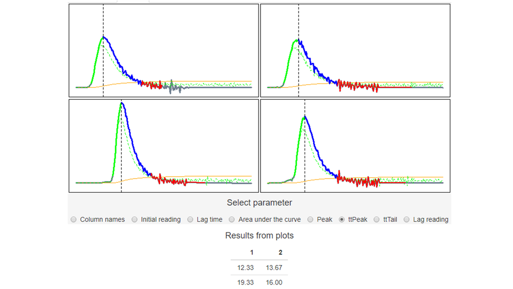

### Curve

In this tab a single curve is selected and shown, along with the results.

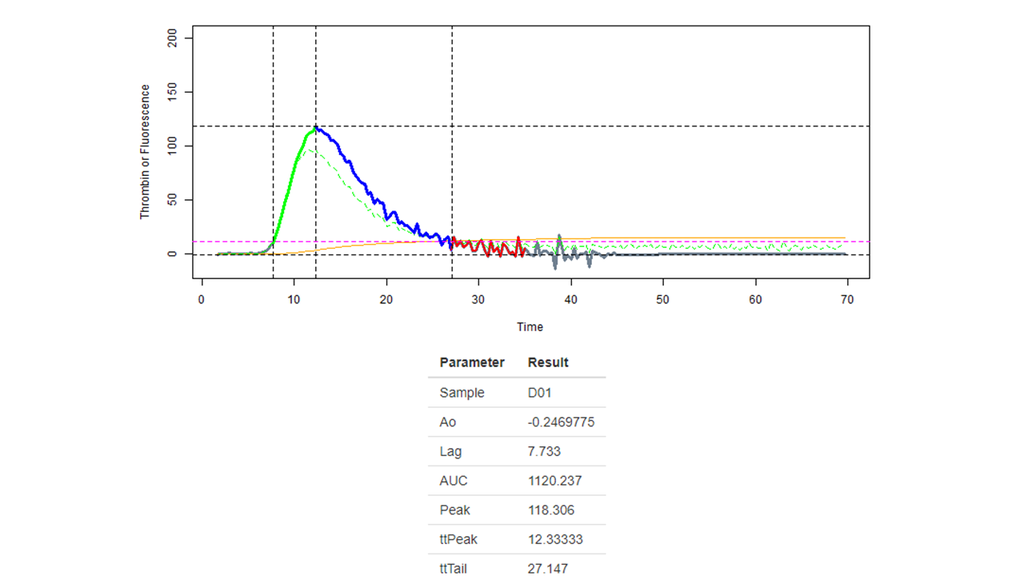

### Results

A table of results is presented here and includes all parameters for all curves. The addition column *Base* measures the time between the lag time and the point where the curve reaches the same Thrombin concentration that triggered the end of the lag phase, shown as the lag reading. These points are also used to calculate the area under the curve.

### Raw Data

All the raw data are shown in this tab. The type of data shown can be changed using the radio buttons as *Raw fluorescence*, *Thrombin*, or *Corrected*, which includes any correction algorithms selected in the left hand pane such as the polynomial transformation or thrombin-alpha-2-macroglobulin complex subtraction. If the app is being run locally a column of data can be selected to be copied to the clipboard for further processing or plotting (this is not active in the online app).

### Settings

A table is presented that collects various settings chosen for an analysis. This can be copied and pasted to be kept with results outputs to help with reproducibility.

### Help

Provides a brief summary of this help file.

R code, data and help files are available from: https://github.com/drclongstaff/Thrombin_Generation_Assays/

Summary of other apps available at: https://drclongstaff.github.io/shiny-clots/

More information and links may be found at http://www.nibsc.org/science_and_research/biotherapeutics/haemostasis/fibrinolysis.aspx